# EasyVisa Project

#### Tuned Bagging classifier

```python
#Tuning the Bagging classifier model
#Choose the type of classifier.
bagging_estimator_tuned = BaggingClassifier(random_state=1)

# Grid of parameters to choose from
## add from article
parameters = {'max_samples': [0.7,0.8,0.9,1],
              'max_features': [0.7,0.8,0.9,1],
              'n_estimators' : [70,80,90,100,110],
             }

# Type of scoring used to compare parameter combinations
acc_scorer = metrics.make_scorer(metrics.f1_score)

# Run the grid search
grid_obj = GridSearchCV(bagging_estimator_tuned, parameters, scoring=acc_scorer,cv=5)
grid_obj = grid_obj.fit(X_train, y_train)

# Set the clf to the best combination of parameters
bagging_estimator_tuned = grid_obj.best_estimator_

# Fit the best algorithm to the data.
bagging_estimator_tuned.fit(X_train, y_train)
```

```
BaggingClassifier(max_features=0.7, max_samples=0.7, n_estimators=100,
                  random_state=1)
```

```python
#Using above defined function to get accuracy, recall,precision and F1score on train and test set
bagging_estimator_tuned_score=get_metrics_score(bagging_estimator_tuned)
```

```
Accuracy on training set :  0.9961874859834043
Accuracy on test set :  0.7242281527995814
Recall on training set :  0.9999160580878033
Recall on test set :  0.8953966699314397
Precision on training set :  0.9944068787043994
Precision on test set :  0.7438567941415786
F1 on training set :  0.9971538590323121
F1 on test set :  0.8126222222222222
```

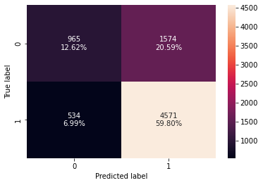

```python
#Checking the confusion matrix for the test set
confusion_matrix_sklearn(bagging_estimator_tuned,X_test,y_test)
```

#### Tuned Random forest classifier

```python
#Tuning the random forest classifier model
#Choose the type of classifier.
rf_estimator_tuned = RandomForestClassifier(random_state=1)

# Grid of parameters to choose from
## add from article
parameters = {"n_estimators": [5,10,15,20],
    "max_features": np.arange (0.2, 0.7, 0.1),
    "min_samples_split": [5, 7],
    "n_estimators": np.arange(15,31,5),
}

# Type of scoring used to compare parameter combinations
acc_scorer = metrics.make_scorer(metrics.f1_score)

# Run the grid search
grid_obj = GridSearchCV(rf_estimator_tuned, parameters, scoring=acc_scorer,cv=5)
grid_obj = grid_obj.fit(X_train, y_train)

# Set the clf to the best combination of parameters
rf_estimator_tuned = grid_obj.best_estimator_

# Fit the best algorithm to the data.
rf_estimator_tuned.fit(X_train, y_train)
```

```
RandomForestClassifier(max_features=0.30000000000000004, min_samples_split=7,
                       n_estimators=30, random_state=1)
```

```python
#Using above defined function to get accuracy, recall,precision and F1score on train and test set
rf_estimator_tuned_score=get_metrics_score(rf_estimator_tuned)
```

```
Accuracy on training set :  0.9342341332137251
Accuracy on test set :  0.7309000523286238
Recall on training set :  0.9758247292873332
Recall on test set :  0.849951028403526
Precision on training set :  0.9292565947242206
Precision on test set :  0.7706927175843694
F1 on training set :  0.9519715022724482
F1 on test set :  0.808383791336749
```

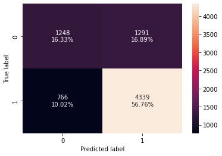

```python
# checking the confusion matrix for the test set
confusion_matrix_sklearn(rf_estimator_tuned,X_test,y_test)
```

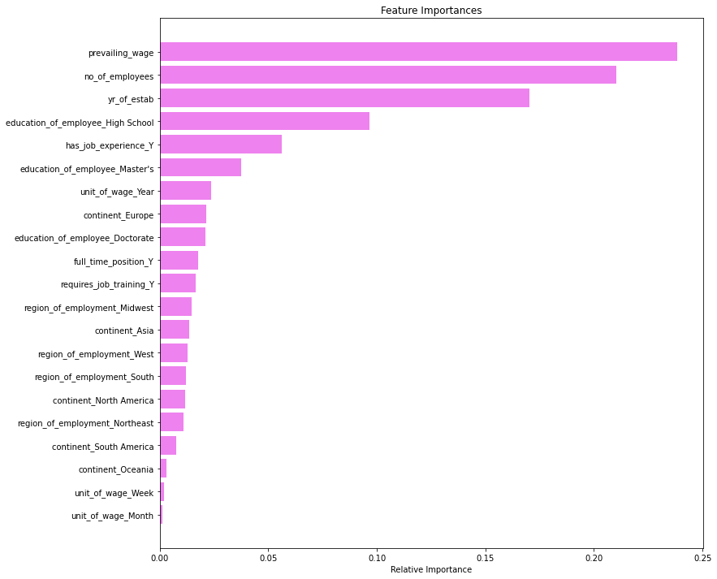

```python
#Checking the important features for this model
feature_names = X_train.columns
importances = rf_estimator_tuned.feature_importances_
indices = np.argsort(importances)

plt.figure(figsize=(12,12))
plt.title('Feature Importances')
plt.barh(range(len(indices)), importances[indices], color='violet', align='center')
plt.yticks(range(len(indices)), [feature_names[i] for i in indices])
plt.xlabel('Relative Importance')
plt.show()
```

Observations:

- The F1 score of 0.81 the random forest model is slightly better after hyper parameter tuning because the recall has improved.
- We can see that it is still not the best model so far, though it is slightly less overfitting than the default parameter model.
- The top 5 important features here are prevailing wage,no of employees, year of establishment,education of employee (high school) and has job experience (Y)

#### Tuned Adaboost classifier

```python
#Adaboost hyperparameter tuning
# Choose the type of classifier.
abc_tuned = AdaBoostClassifier(random_state=1)

# Grid of parameters to choose from
## add from article
parameters = {
    #Let's try different max_depth for base_estimator
    "base_estimator":[DecisionTreeClassifier(max_depth=1, class_weight='balanced', random_state=1),DecisionTreeClassifier(max_depth=2, class_weight='balanced', random_state=1),],
    "n_estimators": np.arange(80,101,10),
    "learning_rate":np.arange(0.1,2,0.1)
}

# Type of scoring used to compare parameter combinations
acc_scorer = metrics.make_scorer(metrics.f1_score)

# Run the grid search
grid_obj = GridSearchCV(abc_tuned, parameters, scoring=acc_scorer,cv=5)
grid_obj = grid_obj.fit(X_train, y_train)

# Set the clf to the best combination of parameters
abc_tuned = grid_obj.best_estimator_

# Fit the best algorithm to the data.
abc_tuned.fit(X_train, y_train)
```

```
AdaBoostClassifier(base_estimator=DecisionTreeClassifier(class_weight='balanced',
                                                         max_depth=1,
                                                         random_state=1),
                   learning_rate=0.1, n_estimators=100, random_state=1)
```

```python
#Using above defined function to get accuracy, recall,precision and F1score on train and test set
abc_tuned_score=get_metrics_score(abc_tuned)
```

```
Accuracy on training set :  0.7189952904238619
Accuracy on test set :  0.7165096807953951
Recall on training set :  0.7812473768152438
Recall on test set :  0.7813907933398628
Precision on training set :  0.7945872107914284
Precision on test set :  0.7914682539682539
F1 on training set :  0.7878608312875646
F1 on test set :  0.7863972400197141
```

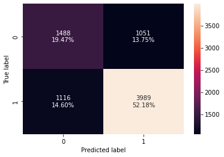

```python
#Checking the confusion matrix for the test set
confusion_matrix_sklearn(abc_tuned,X_test,y_test)
```

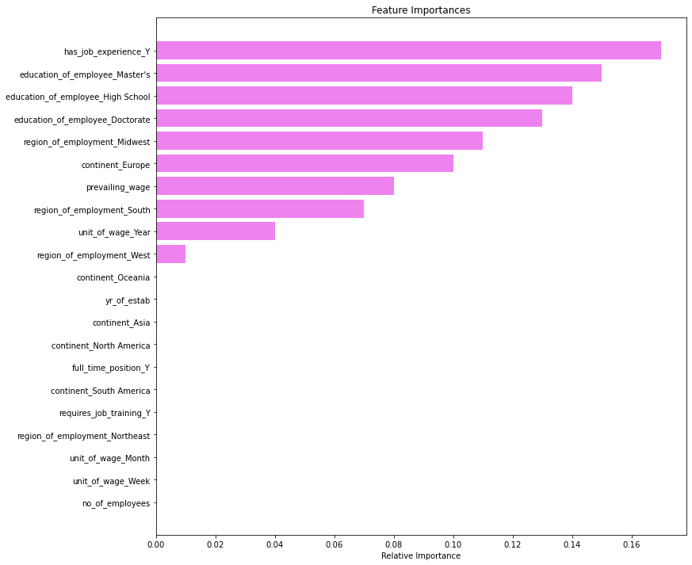

```python
#Checking the important features of the model
importances = abc_tuned.feature_importances_
indices = np.argsort(importances)
feature_names = list(X.columns)

plt.figure(figsize=(12,12))
plt.title('Feature Importances')
plt.barh(range(len(indices)), importances[indices], color='violet', align='center')
plt.yticks(range(len(indices)), [feature_names[i] for i in indices])
plt.xlabel('Relative Importance')
plt.show()
```

Observations:

- The performance of the adaboost model tree is much better in the default model than after hyperparameter tuning.
- The default gives a better f1 score.
- The tuned model is equally as stable as the default, but overall the performance is poorer in the tuned model
- Here, the top 5 important features are has job experience (Y), Education of employee ( masters, high school and doctorate) and region of employment (midwest)

#### Tuned GB classifier

```python
#Tuning GB
# Choose the type of classifier.
gbc_tuned = GradientBoostingClassifier(init=AdaBoostClassifier(random_state=1),random_state=1)

# Grid of parameters to choose from
## add from article
parameters = {
    "n_estimators": [100,150,200,250],
    "subsample":[0.8,0.9,1],
    "max_features":[0.7,0.8,0.9,1],
    "learning_rate": np.arange(0.1,0.21,0.1),
}

# Type of scoring used to compare parameter combinations
acc_scorer = metrics.make_scorer(metrics.recall_score)

# Run the grid search
grid_obj = GridSearchCV(gbc_tuned, parameters, scoring=acc_scorer,cv=5)
grid_obj = grid_obj.fit(X_train, y_train)

# Set the clf to the best combination of parameters
gbc_tuned = grid_obj.best_estimator_

# Fit the best algorithm to the data.
gbc_tuned.fit(X_train, y_train)
```

```
GradientBoostingClassifier(init=AdaBoostClassifier(random_state=1),
                           max_features=1, random_state=1, subsample=1)
```

```python
#Using above defined function to get accuracy, recall,precision and F1score on train and test set
gbc_tuned_score=get_metrics_score(gbc_tuned)
```

```
Accuracy on training set :  0.7334043507512895
Accuracy on test set :  0.7231815803244375
Recall on training set :  0.923780743725342
Recall on test set :  0.9198824681684623
Precision on training set :  0.7409776461082682
Precision on test set :  0.7334062158363267
F1 on training set :  0.8223426116196526
F1 on test set :  0.8161279110184219
```

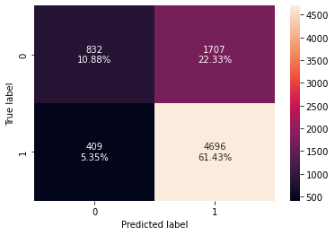

```python
#Checking the confusion matrix for the test set
confusion_matrix_sklearn(gbc_tuned,X_test,y_test)
```

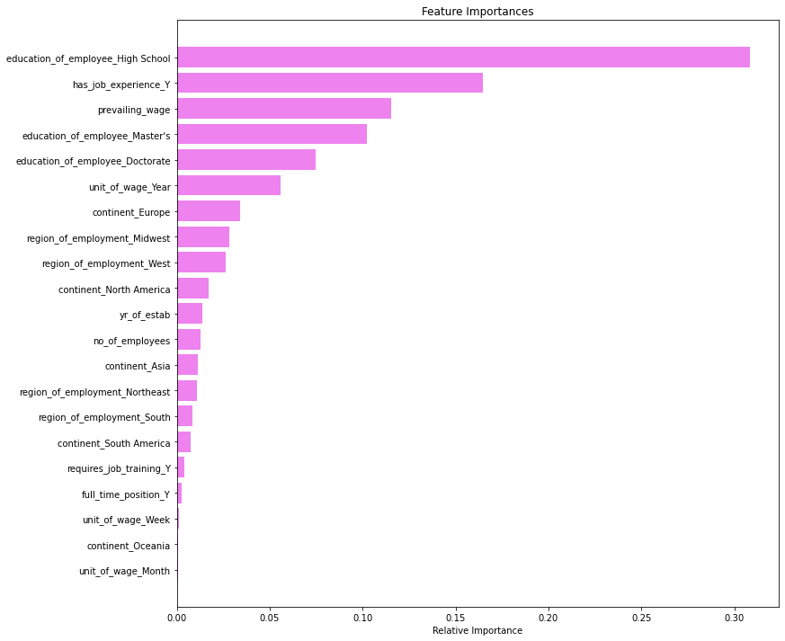

```python
# Checking the important features
importances = gbc_tuned.feature_importances_
indices = np.argsort(importances)
feature_names = list(X.columns)

plt.figure(figsize=(12,12))
plt.title('Feature Importances')
plt.barh(range(len(indices)), importances[indices], color='violet', align='center')
plt.yticks(range(len(indices)), [feature_names[i] for i in indices])
plt.xlabel('Relative Importance')
plt.show()
```

#### XGboost classifier

```python
#Tuning XGBoost
# Choose the type of classifier.
xgb_tuned = XGBClassifier(random_state=1,eval_metric='logloss')

# Grid of parameters to choose from
## add from
parameters = {
    "n_estimators": [150,200,250],
    "scale_pos_weight":[1,2,],
    "subsample":[0.9,1],
    "learning_rate":[0.1,0.2,0.3],
    "gamma":[3,5],
    "colsample_bytree":[0.8,0.9],
    "colsample_bylevel":[0.9,1]
}

# Type of scoring used to compare parameter combinations
acc_scorer = metrics.make_scorer(metrics.recall_score)

# Run the grid search
grid_obj = GridSearchCV(xgb_tuned, parameters,scoring=acc_scorer,cv=5)
grid_obj = grid_obj.fit(X_train, y_train)

# Set the clf to the best combination of parameters
xgb_tuned = grid_obj.best_estimator_

# Fit the best algorithm to the data.
xgb_tuned.fit(X_train, y_train)
```

```
XGBClassifier(base_score=0.5, booster='gbtree', callbacks=None,
              colsample_bylevel=1, colsample_bynode=1, colsample_bytree=0.8,
              early_stopping_rounds=None, enable_categorical=False,
              eval_metric='logloss', gamma=5, gpu_id=-1,
              grow_policy='depthwise', importance_type=None,
              interaction_constraints='', learning_rate=0.1, max_bin=256,
              max_cat_to_onehot=4, max_delta_step=0, max_depth=6, max_leaves=0,
              min_child_weight=1, missing=nan, monotone_constraints='()',
              n_estimators=150, n_jobs=0, num_parallel_tree=1, predictor='auto',
              random_state=1, reg_alpha=0, reg_lambda=1, ...)
```

```python
#Using above defined function to get accuracy, recall,precision and F1score on train and test set
xgb_tuned_score=get_metrics_score(xgb_tuned)
```

```
Accuracy on training set :  0.7545974433729535
Accuracy on test set :  0.7210884353741497
Recall on training set :  0.9750692520775623
Recall on test set :  0.9535749265426053
Precision on training set :  0.7400611620795107
Precision on test set :  0.7197989058110306
F1 on training set :  0.8414647397587743
F1 on test set :  0.8203572632288507
```

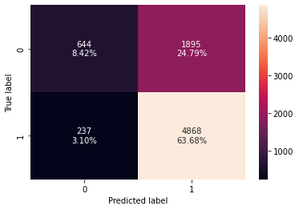

```python
#Checking the confusion matrix for the test set
confusion_matrix_sklearn(xgb_tuned,X_test,y_test)
```

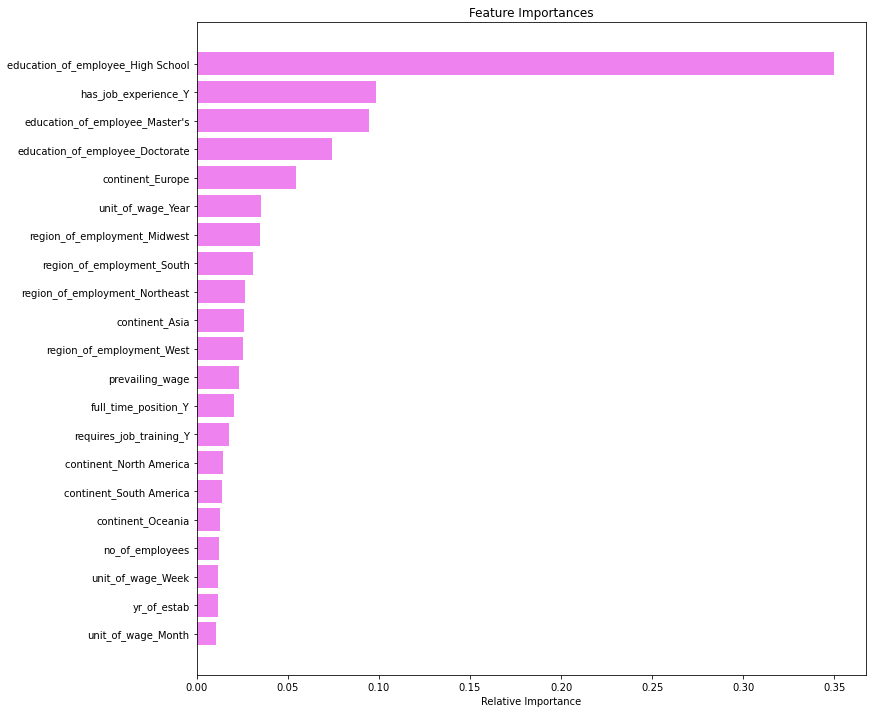

```python
# Checking the important features
importances = xgb_tuned.feature_importances_
indices = np.argsort(importances)
feature_names = list(X.columns)

plt.figure(figsize=(12,12))
plt.title('Feature Importances')
plt.barh(range(len(indices)), importances[indices], color='violet', align='center')
plt.yticks(range(len(indices)), [feature_names[i] for i in indices])
plt.xlabel('Relative Importance')
plt.show()
```

#### Stacking classifier

```python
#Stacking Classifier
estimators = [
    ("AdaBoost", abc),
    ("Gradient Boosting", gbc_tuned),
    ("Random Forest", rf_estimator_tuned),
]

final_estimator = xgb_tuned

stacking_classifier= StackingClassifier(estimators=estimators,final_estimator=final_estimator)

stacking_classifier.fit(X_train,y_train)
```

```
StackingClassifier(estimators=[('AdaBoost', AdaBoostClassifier(random_state=1)),
                               ('Gradient Boosting',
                                GradientBoostingClassifier(init=AdaBoostClassifier(random_state=1),
                                                           max_features=1,
                                                           random_state=1,
                                                           subsample=1)),
                               ('Random Forest',
                                RandomForestClassifier(max_features=0.30000000000000004,
                                                       min_samples_split=7,
                                                       n_estimators=30,
                                                       random_state=1))],
                   final_estimato...
                                                 eval_metric='logloss', gamma=5,
                                                 gpu_id=-1,
                                                 grow_policy='depthwise',
                                                 importance_type=None,
                                                 interaction_constraints='',
                                                 learning_rate=0.1, max_bin=256,
                                                 max_cat_to_onehot=4,
                                                 max_delta_step=0, max_depth=6,
                                                 max_leaves=0,
                                                 min_child_weight=1,
                                                 missing=nan,
                                                 monotone_constraints='()',
                                                 n_estimators=150, n_jobs=0,
                                                 num_parallel_tree=1,
                                                 predictor='auto',
                                                 random_state=1, reg_alpha=0,
                                                 reg_lambda=1, ...))
```

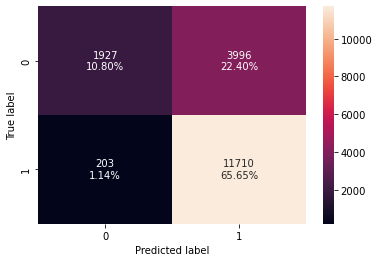

```python
#Checking the confusion matrix of the train set
confusion_matrix_sklearn(stacking_classifier,X_train,y_train)
```

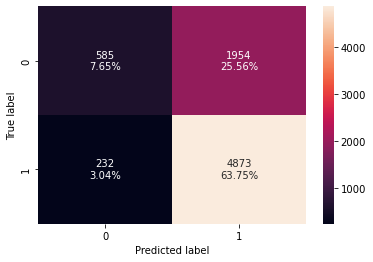

```python
#Checking the confusion matrix on the test set
confusion_matrix_sklearn(stacking_classifier,X_test, y_test)
```

```python
#Using above defined function to get accuracy, recall,precision and F1score on train and test set
stacking_classifier_model_perf = get_metrics_score(stacking_classifier)
stacking_classifier_model_perf
```

```
Accuracy on training set :  0.7645772594752187
Accuracy on test set :  0.7140240711669283
Recall on training set :  0.9829597918240578
Recall on test set :  0.9545543584720861
Precision on training set :  0.7455749395135617
Precision on test set :  0.7137835066647137
F1 on training set :  0.8479669792534125
F1 on test set :  0.8167951726449884
```

```
[0.7645772594752187,
 0.7140240711669283,
 0.9829597918240578,
 0.9545543584720861,
 0.7455749395135617,
 0.7137835066647137,
 0.8479669792534125,
 0.8167951726449884]
```

Observations:

- The model performs good on bothe training and testing data and has a nice F1 score of 0.82
- There is very little or no overfitting

## Model Performance Comparison and Conclusions

```python
# defining list of models
models = [decision_tree, Decision_tree_tuned, bagging_estimator, bagging_estimator_tuned, rf_estimator, rf_estimator_tuned,abc, abc_tuned, gbc, gbc_tuned, xgb, xgb_tuned, stacking_classifier]

# defining empty lists to add train and test results
acc_train = []
acc_test = []
recall_train = []
recall_test = []
precision_train = []
precision_test = []
F1_score_train = []
F1_score_test = []

# looping through all the models to get the accuracy, recall, precision scores and F1 score
for model in models:
    j = get_metrics_score(model, False)
    acc_train.append(np.round(j[0],2))
    acc_test.append(np.round(j[1],2))
    recall_train.append(np.round(j[2],2))
    recall_test.append(np.round(j[3],2))
    precision_train.append(np.round(j[4],2))
    precision_test.append(np.round(j[5],2))
    F1_score_train.append(np.round(j[6],2))
    F1_score_test.append(np.round(j[7],2))
```

```python
comparison_frame = pd.DataFrame({'Model':['Decision tree', 'Decision tree tuned', 'Bagging estimator', 'Bagging estimator tuned', 'Random forest', 'Random Forest Tuned','AdaBoost with default paramters','AdaBoost Tuned',
                                          'Gradient Boosting with default parameters',
                                          'Gradient Boosting Tuned','XGBoost with default parameters','XGBoost Tuned', 'Stacking classifier'],
                                          'Train_Accuracy': acc_train,'Test_Accuracy': acc_test,
                                          'Train_Recall':recall_train,'Test_Recall':recall_test,
                                          'Train_Precision':precision_train,'Test_Precision':precision_test,'Train_F1':F1_score_train,'Test_F1':F1_score_test })
comparison_frame
```

|  | Model | Train_Accuracy | Test_Accuracy | Train_Recall | Test_Recall | Train_Precision | Test_Precision | Train_F1 | Test_F1 |
| --- | --- | --- | --- | --- | --- | --- | --- | --- | --- |
| 0 | Decision tree | 1.00 | 0.66 | 1.00 | 0.74 | 1.00 | 0.75 | 1.00 | 0.75 |
| 1 | Decision tree tuned | 0.71 | 0.71 | 0.93 | 0.93 | 0.72 | 0.72 | 0.81 | 0.81 |
| 2 | Bagging estimator | 0.99 | 0.69 | 0.99 | 0.76 | 0.99 | 0.77 | 0.99 | 0.77 |
| 3 | Bagging estimator tuned | 1.00 | 0.72 | 1.00 | 0.90 | 0.99 | 0.74 | 1.00 | 0.81 |
| 4 | Random forest | 1.00 | 0.72 | 1.00 | 0.83 | 1.00 | 0.77 | 1.00 | 0.80 |
| 5 | Random Forest Tuned | 0.93 | 0.73 | 0.98 | 0.85 | 0.93 | 0.77 | 0.95 | 0.81 |
| 6 | AdaBoost with default paramters | 0.74 | 0.73 | 0.89 | 0.89 | 0.76 | 0.76 | 0.82 | 0.82 |
| 7 | AdaBoost Tuned | 0.72 | 0.72 | 0.78 | 0.78 | 0.79 | 0.79 | 0.79 | 0.79 |
| 8 | Gradient Boosting with default parameters | 0.76 | 0.74 | 0.88 | 0.88 | 0.78 | 0.77 | 0.83 | 0.82 |
| 9 | Gradient Boosting Tuned | 0.73 | 0.72 | 0.92 | 0.92 | 0.74 | 0.73 | 0.82 | 0.82 |
| 10 | XGBoost with default parameters | 0.84 | 0.73 | 0.93 | 0.86 | 0.84 | 0.77 | 0.89 | 0.81 |
| 11 | XGBoost Tuned | 0.75 | 0.72 | 0.98 | 0.95 | 0.74 | 0.72 | 0.84 | 0.82 |
| 12 | Stacking classifier | 0.76 | 0.71 | 0.98 | 0.95 | 0.75 | 0.71 | 0.85 | 0.82 |

### Observations from the Model comparisons

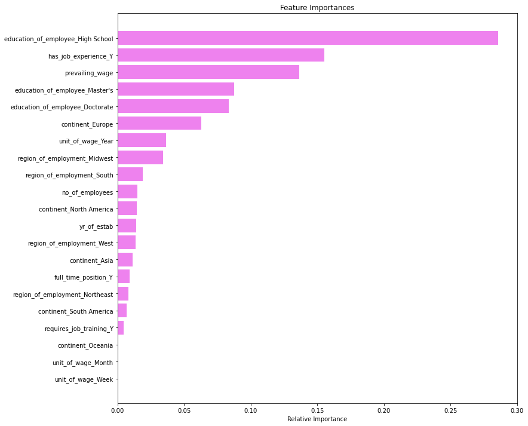

```python
#Checking the important features in the most preferred model
feature_names = X_train.columns
importances = gbc.feature_importances_
indices = np.argsort(importances)

plt.figure(figsize=(12, 12))
plt.title("Feature Importances")
plt.barh(range(len(indices)), importances[indices], color="violet", align="center")
plt.yticks(range(len(indices)), [feature_names[i] for i in indices])
plt.xlabel("Relative Importance")
plt.show()
```

```python
#Computing the important features in the tree building in a normalized form
print(pd.DataFrame(gbc.feature_importances_, columns = ["Imp"],
                   index = X_train.columns).sort_values(by = 'Imp', ascending = False).head(10))
```

```
                                        Imp
education_of_employee_High School  0.285978
has_job_experience_Y               0.155462
prevailing_wage                    0.136663
education_of_employee_Master's     0.087565
education_of_employee_Doctorate    0.083538
continent_Europe                   0.063035
unit_of_wage_Year                  0.036526
region_of_employment_Midwest       0.034432
region_of_employment_South         0.019024
no_of_employees                    0.014866
```

## Actionable Insights and Recommendations

### Insights

- Considering the EDA and the GB Classifier model, the top 10 most important features to decide whether a visa gets certified or denied are Education of employee (High school, masters and doctorate), Has Job experience (Y), prevailing wage, Continent (Europe), Unit of wage (Year),Region of employment (Midwest and South) and number of employees.
- The most important feature with a magnitude of 0.29 is the education of employee. From the EDA, we saw that if an employee possesses a high school degree (likely as the highest level of qualification), that employee is more likely to be denied than accepted. Employees with doctorate degrees have the highest chances of getting certified, so they should be encouraged to apply. Likewise employees with masters degrees, also have better chances than those with high school degrees and should also be encouraged to apply for roles.
- If an employee has job experience, they are more likely to be certified than those who do not have prior job experience. those without experience are likely to be denied.
- If an employee is from Europe, he has greater chances of getting certified than any other continent.
- Employees with a higher prevailing wage are likely to be certified, and this is in line with the unit of wage being in years.
- When the pay unit is in years, there are greater chances of being certified than if it is a different pay unit.
- If the region of employment is midwest or south, employees have higher chances of being certified than denied. employees who apply to other regions have higher chances of being denied.
- With respect to the number of employees, the higher the number of employees, the higher the chances of getting approved.
- Interestingly, other factors like requirement for job training, year of establishment and full time or part time employment, do not appear to affect the denial or certification significantly

### Recommendations

- To make the otherwise tedius task of screening a lot easier, the OFLC can prioritize employees from Europe with higher degrees, who have some job experience and with the intention of getting employed in Midwest or south at a company with large number of employees and which uses years as the pay unit. They can shortlist applications that fall under this category first and there after review other applications
- They can also educate the employing companies and encourage them to adjust their job ads or job application requirements based on the important features, so that they attract candidates that have better chances of getting their visas certified.
- The OFLC can also implement (or advise the concerned department to implement) specialized worker programs that specifically attract talent based on consideration of these important features, so that they can possibly focus on that program for employees. They could use some of the important features as an eligibility criteria. It is also a win for employers as they can go to the same pool to find suitable employees for their businesses.
- They could also implement a point system for employees, with the important features deciding which criteria should be scored and how they can be scored. The summary of their details are quantified into points and the OFLC can begin to screen the applicants with the higher points first.